# Chapter 6: Various stuff, but mostly quantiles

S350

These notes are written to accompany Trosset chapter 6. This chapter of Trosset is pretty succinct, however, so you might as well just read that.

## Symmetry

*Trosset ch. 6.1*

A discrete or continuous random variable with expected value $\mu$ is symmetric if and only if:

$$f(\mu + x) = f(\mu - x)$$

The definition gets a bit more complicated if the random variables is neither discrete nor continuous, or if there’s no finite expected value (see Trosset Definition 6.2), but this isn’t really something worth worrying about.

In practice, to check if a continuous variable is symmetric, draw the PDF. If there’s a vertical line such that the left-hand side is the mirror image of the right-hand side, the random variable is symmetric. Otherwise, it’s not.

If, instead of being symmetric, the PDF is stretched out to the right-hand side, we call the distribution **right-skewed**. If the PDF is stretched out to the left-hand side, it’s **left-skewed**. We should note, however, that these ideas are not quite as easy to make precise as we might hope, and many random variables are not well-described as either symmetric or skewed – for example, when the PDF has two unequal peaks. If it takes more than one word to describe the PDF, then use more than one word.

## Quantiles

*Trosset ch. 6.2*

A CDF answers the question: Given a value of the random variable, what is the “less than or equal to” probability? But we could also ask the opposite question: Given a “less than or equal to” probability, what is the corresponding value of the random variable.

Formally, let $X$ be a random variable and choose $\alpha$ such that $0 < \alpha < 1$. If $q$ is such that

$$P(X < q) \le \alpha$$

and

$$P(X > q) \ge 1 - \alpha$$

then $q$ is an $\alpha$-quantile of $X$.

For continuous random variables, the $\alpha$-quantile exists for all $\alpha$ (though it may not be unique; see below.) We can find a general expression for quantiles by inverting the CDF: set $F(q) = \alpha$ and solve for $q$.

**Example.** A Uniform$(a,b)$ random variable has CDF

$$F(y) = \left\{
\begin{array}{cl}
0 & y < a \\
\frac{y-a}{b-a} & a \le y < b \\
1 & y \ge b
\end{array}
\right.$$

We’re only worried about the middle part.

$$\begin{aligned}
F(q) &=& \alpha \\
\frac{q-a}{b-a} &=& \alpha \\
q &=& a + \alpha(b-a)
\end{aligned}$$

## Population median

The **population median**, denoted $q_2$, is the 0.5-quantile of a random variable. For a well-behaved continuous random variable:

$$\begin{aligned}
P(X < q) &= 0.5 \\
P(X > q) &= 0.5
\end{aligned}$$

However, a distribution may not have just one 0.5-quantile: it may have an interval of values that all satisfy the definition of 0.5-quantile. (This can happen when there is a “gap” in the PDF.) If this is the case, take the midpoint of the interval of all values that satisfy the definition of 0.5-quantile.

For a symmetric distribution, the median is the same as the expected value.

## Quartiles and IQR

- The 0.25-quantile is called the **first quartile** ($q_1$).
- The 0.5-quantile is called the **second quartile** ($q_2$).
- The 0.75-quantile is called the **third quartile** ($q_3$).

The **interquartile range**, or **IQR**, is $q_3 - q_1$. Like the standard deviation, it’s a measure of spread on the same scale as the original random variable.

## qnorm()

The R function `qnorm()` is used to find quantiles of the Normal. By default, the function uses a standard normal; otherwise you need to specify mean and standard deviation.

```r
# Median of the standard normal
qnorm(0.5)
```

```
## [1] 0
```

```r
# Find the IQR
qnorm(0.75) - qnorm(0.25)
```

```
## [1] 1.34898
```

```r
# Let X be Normal(0, 10^2)
# Find the IQR
qnorm(0.75, mean=0, sd=10) - qnorm(0.25, mean=0, sd=10)
```

```
## [1] 13.4898
```

### rnorm() and simulation

The function `rnorm()` generates random independent realizations of a Normal random variable. We can use these in **simulations** to study problems that are hard to solve analytically.

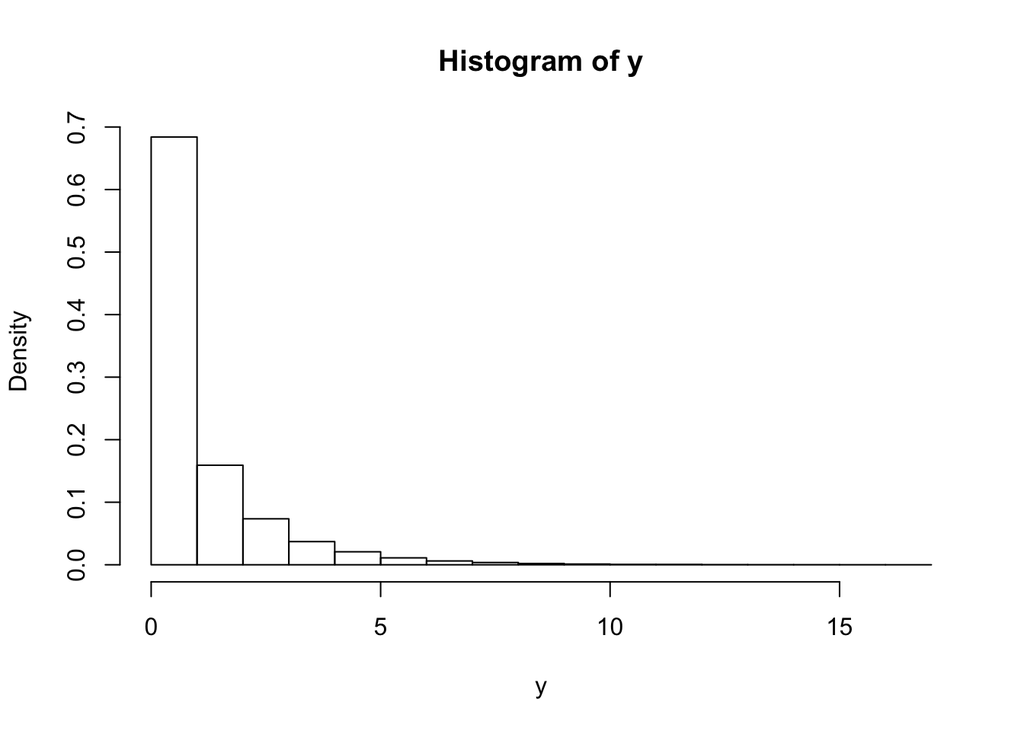

```r
z = rnorm(100000)
y = z^2
# Draw a histogram
hist(y, prob=TRUE)
```

```r
mean(y)
```

```
## [1] 0.9993402
```

## Least squares

I don’t have anything interesting to say about least squares, so just read Trosset ch. 6.3.